# Geosurvey_ML

## PHASE 1 - STRATEGY

### PROBLEM DEFINITION

Geotechnical Ground Drilling is performed in many locations using Cone Penetration Test(CPD) where soil samples are taken at various depths(usually every 2.5cm) and are taken to a laboratory for testing. After laboratory tests, a laboratory report is drawn up where the soil type for a range of depths is determined and saved in a worksheet and each soil type encountered in that drill site is stored in a spreadsheet in the worksheet.

This led to an amassed data lake consisting of drill data files(.snd) and laboratory reports of the obtained soil samples(.xlsx/.xlsm).

```
                          drill data(.snd)                         workbook(.xlsx/.xlsm)
```

> *The drill data consists of readings such as the longitudinal and latitudinal coordinates of the drill site, the height above sea level of the drill site, unique identifier, date drilling took place. The table consists of drill depth, drill pressure, drill torque and drill flushing pressure. The laboratory worksheet consists of several differently named spreadsheets with each containing the soil type at a range of depth.*

**The question then became how could this stored data be mined in order to understand how soil type relates with other data and how this other data could "tell" what type of soil a sample is without having to do an expensive laboratory test.**

### PROBLEM SOLUTION

A Machine learning approach was considered to solve this problem where data would be fed into a suitable classification machine learning algorithm(Lightgbm) which will learn the relationship between the dependent variable (soil type) and other variables (drill depth, pressure etc.) and be able to predict the soil type of new unseen data given other variables accurately and swiftly.

- The first step was to create a dataset from the wealth of drill data and laboratory report files by extracting important data points in the drill data file and merging it with equally important data points in its sibling laboratory report.
- The next step was to clean the new dataset by removing empty and incomplete rows and performing feature engineering through exploratory data analysis by balancing the dataset classes.
- The final step was then passing this clean and feature engineered dataset into an appropriately tuned machine learning algorithm where the algorithm would be able to predict soil type given other indicators(variables).

### SCOPE DEFINITION

The program developed for this project will be able to access the directory where the data files are stored and be able to match each drill data file with its sibling laboratory report file in the same sub-directory and extract the important data points from each file, merge them together and repeat for all files in all sub-directories. Also, only spreadsheets named with integer numbers are considered in each workbook.

It will also clean up the output dataset and perform feature engineering techniques on it. After this, it will split the cleaned set into a training set and test/validation set and finally pass the train set through the Lightgbm ML algorithm to be able to predict soil type on the test/validation set and validate these predictions. It will also detail model metrics and results.

### FEASABILITY DEFINITION

This project would help save precious resources and time in determining the soil type at various locations and depths. This would enable faster decisions in managing soil and land in those locations.

### PLAN OF DEVELOPMENT

The project was developed modularly using python programming language. The modules include the data extraction module, the data cleaning module and the data modelling module. It was developed using the Anaconda package Jupyter Notebook and the code was exported to a python file(.py) which can be run in standard IDEs.

It made use of library packages such as pandas for data manipulations, text parsing and cleaning, openpyxl for parsing xlsx and xlsm documents and extracting data, matplotlib for data visualizations and many more.

After developing the data model using the files available, the final data model would be tested and fitted with more data until a desirable performance metric is achieved, then it would be deployed for use outside of the local machine and be used real-time prediction while learning on new data in streams on the cloud.

```
import re
import openpyxl
import numpy as np
import pandas as pd
import seaborn as sns
import matplotlib.pyplot as plt
```

> *Some Libraries used*

## PHASE 2 - DATA PREPARATION AND PREPROCESSING

### DATA COLLECTION

The data files from many years (drill and laboratory) were obtained from data repositories hosted on several severs and were downloaded into multiple folders based on the drilling location over time. These file folders contained numerous data files from different drill wells in the same location and other files such as images and text files.

These file folders are also split into other folders where drill data and laboratory report are stored separately.

### DATA VISUALIZATION

```python
from IPython.display import display
from IPython.display import HTML
import IPython.core.display as di # Example: di.display_html('<h3>%s:</h3>' % str, raw=True)

# This line will hide code by default when the notebook is exported as HTML
di.display_html('<script>jQuery(function() {if (jQuery("body.notebook_app").length == 0) { jQuery(".input_area").toggle(); jQuery(".prompt").toggle();}});</script>', raw=True)

# This line will add a button to toggle visibility of code blocks, for use with the HTML export version
di.display_html('''<button onclick="jQuery('.input_area').toggle(); jQuery('.prompt').toggle();">Toggle code</button>''', raw=True)

import warnings
warnings.filterwarnings('ignore')
import numpy as np
import pandas as pd
import seaborn as sns
import matplotlib.pyplot as plt
%matplotlib inline
from sklearn.model_selection import train_test_split, GridSearchCV, cross_val_score
from sklearn import metrics
from lightgbm import LGBMClassifier
import shap

dataset = pd.read_csv(r"data_extract.csv", index_col = 0)
dataset = dataset.dropna(axis=0, how='any', thresh=None, subset=None, inplace=False)

y = dataset["Soil type"]
X = dataset.drop("Soil type", axis = 1)

X_train, X_test, y_train, y_test = train_test_split(X, y, test_size = 0.3, random_state = 50)

gbm = LGBMClassifier(boosting_type = 'gbdt', colsample_bytree = 0.8, learning_rate = 0.1,
                     n_estimators = 400, num_leaves = 20, objective = 'multiclass',
                     random_state = 42, reg_alpha = 0.5, reg_lambda = 0.5, subsample = 0.75)

gbm.fit(X_train, y_train)
Y_sum = gbm.predict(X_test)

gridParams = {
    'learning_rate': [0.1, 0.05],
    'n_estimators': [40, 200, 400],
    'num_leaves': [20, 40],
    'boosting_type' : ['gbdt'],
    'objective' : ['multiclass'],
    'random_state' : [42],
    'colsample_bytree' : [0.8, 1],
    'subsample' : [0.75,1],
    'reg_alpha' : [1,0.5],
    'reg_lambda' : [1,0.5],
    }

model = LGBMClassifier()
model.fit(X_train, y_train)

grid = GridSearchCV(model, gridParams,
                    verbose=0,
                    cv=4,
                    n_jobs=2)

grid.fit(X_train, y_train);
```

For exploratory data analysis purposes, the dataset was visualized on some features in order to determine how related they are to the soil type

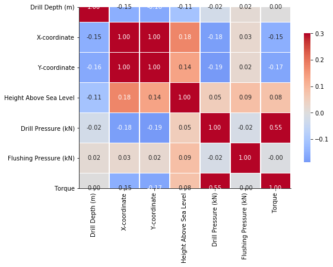

```python
# This line will hide code by default when the notebook is exported as HTML
di.display_html('<script>jQuery(function() {if (jQuery("body.notebook_app").length == 0) { jQuery(".input_area").toggle(); jQuery(".prompt").toggle();}});</script>', raw=True)

# This line will add a button to toggle visibility of code blocks, for use with the HTML export version
di.display_html('''<button onclick="jQuery('.input_area').toggle(); jQuery('.prompt').toggle();">Toggle code</button>''', raw=True)

corr = dataset.corr()
g = sns.heatmap(corr,  vmax=.3, center=0,
            square=True, linewidths=.5, cbar_kws={"shrink": .5}, annot=True, fmt='.2f', cmap='coolwarm')
sns.despine()
g.figure.set_size_inches(8,8)

plt.show()
```

The above figure is a correlation plot of the features to each other exclusive of the dependent variable(soil type). This gives a breakdown of the relationship between the features where a positive score means there is a level of correlation and a negative score means there is a level of uncorrelation.

The next step is to consider the relationship between some of these features and the dependent variable. The first were the drill depth and pressure against the various soil types.

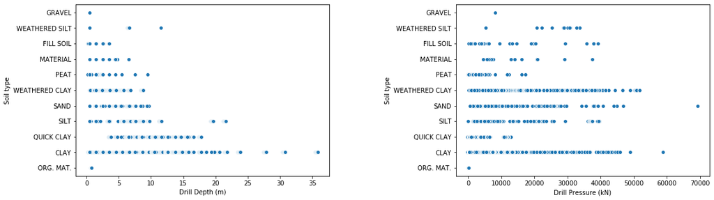

```python
# This line will hide code by default when the notebook is exported as HTML
di.display_html('<script>jQuery(function() {if (jQuery("body.notebook_app").length == 0) { jQuery(".input_area").toggle(); jQuery(".prompt").toggle();}});</script>', raw=True)

# This line will add a button to toggle visibility of code blocks, for use with the HTML export version
di.display_html('''<button onclick="jQuery('.input_area').toggle(); jQuery('.prompt').toggle();">Toggle code</button>''', raw=True)

f, axes = plt.subplots(1, 2, figsize = (18,5))
plt.subplots_adjust(wspace = 0.5)

sns.scatterplot(x='Drill Depth (m)',y='Soil type',data=dataset, ax=axes[0])
sns.scatterplot(x='Drill Pressure (kN)',y='Soil type',data=dataset, ax=axes[1])

plt.show()
```

The results show that soil types such as weathered clay and fill soil span over a large range of drill pressure hence are found over a wide depth of drill pressure whereas they are found at higher ground usually less than 10m of depth. Quick clay is also found at lower drill pressure at a relatively wide range of drill depth.

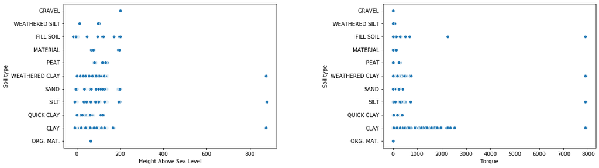

```python
# This line will hide code by default when the notebook is exported as HTML
di.display_html('<script>jQuery(function() {if (jQuery("body.notebook_app").length == 0) { jQuery(".input_area").toggle(); jQuery(".prompt").toggle();}});</script>', raw=True)

# This line will add a button to toggle visibility of code blocks, for use with the HTML export version
di.display_html('''<button onclick="jQuery('.input_area').toggle(); jQuery('.prompt').toggle();">Toggle code</button>''', raw=True)


f, axes = plt.subplots(1, 2, figsize = (18,5))
plt.subplots_adjust(wspace = 0.5)

sns.scatterplot(x='Height Above Sea Level',y='Soil type',data=dataset, ax=axes[0])
sns.scatterplot(x='Torque',y='Soil type',data=dataset, ax=axes[1])

plt.show()
```

The same operation was performed on the "Height above sea level" and "Torque" features with the soil types. The results here shows that those two features have a similar effect on the type of soil encountered.

### DATA SELECTION

In order to build a useful dataset from these data files, the data extraction module was built with the python program to first find all laboratory reports in the project folder(since almost all laboratory reports had a corresponding drill data file but not vice versa), then match those laboratory folders with their corresponding drill data file and pair both and add to a list.

From the drill data files(.snd), the data selected were the X and Y coordinates of the drill well, height above sea level and the table data which contained the drill depth, drill pressure, flushing pressure and torque for each drill step.

From the laboratory report workbooks, the range of drill depths in each spreadsheet inside the workbook were obtained alongside the soil type for those ranges in spreadsheets named with integer numbers.

For the drill data, 1,2,3,12,13,14 and 15 were extracted, while in the workbook, for any integer named spreadsheet, the D column between row 8 and 12 was searched for the range of depths tested on by the laboratory and the O and Q column with row 24 was searched for the soil type which was in Norwegian.

### DATA LABELING

The soil types from the laboratory report were labelled in Nowegian and hence had to translated to English. A dictionary was created which housed the Norwegian words for the different soil types and their English translation. This was then used to relabel the soil types for a simple understanding.

```python
# This line will hide code by default when the notebook is exported as HTML
di.display_html('<script>jQuery(function() {if (jQuery("body.notebook_app").length == 0) { jQuery(".input_area").toggle(); jQuery(".prompt").toggle();}});</script>', raw=True)

# This line will add a button to toggle visibility of code blocks, for use with the HTML export version
di.display_html('''<button onclick="jQuery('.input_area').toggle(); jQuery('.prompt').toggle();">Toggle code</button>''', raw=True)


soil_type = {'LEIRE': 'CLAY', 'KVIKKLEIRE': 'QUICK CLAY', 'TØRRSKORPELEIRE': 'WEATHERED CLAY',
             'SILT': 'SILT', 'TØRRSKORPESILT': 'WEATHERED SILT', 'SAND': 'SAND',
             'GRUS': 'GRAVEL', 'TORV': 'PEAT', 'GYTJE': 'GYTJA',
             'ORG. MATR.': 'ORG. MAT.', 'MATJORD': 'TOPSOIL', 'DY': 'DY',
             'MATERIALE': 'MATERIAL', 'FYLLMASSE': 'FILL SOIL'}

translate_df = pd.DataFrame(soil_type.items(), columns = ['Norwegian', 'English'])
print(translate_df)
```

```
          Norwegian         English
0             LEIRE            CLAY
1        KVIKKLEIRE      QUICK CLAY
2   TØRRSKORPELEIRE  WEATHERED CLAY
3              SILT            SILT
4    TØRRSKORPESILT  WEATHERED SILT
5              SAND            SAND
6              GRUS          GRAVEL
7              TORV            PEAT
8             GYTJE           GYTJA
9        ORG. MATR.       ORG. MAT.
10          MATJORD         TOPSOIL
11               DY              DY
12        MATERIALE        MATERIAL
13        FYLLMASSE       FILL SOIL
```

### DATA TRANSFORMATION

The drill data files in the pair list were parsed and important data points such as drill well location, height above sea level, drill pressure, drill depth etc. were obtained and put into a dataframe. The laboratory workbooks were also parsed and the drill range and soil type for each spreadsheet was obtained for spreadsheets named with numerical integers within the workbook and this was also put into a dataframe.

The final operation was then merging the two dataframes together in order to produce a dataset for that pair list. This entire operation was then repeated for all pairs in the pair list thereby producing a full dataset. Incompatible pairs with missing columns or empty values were saved into a list for later analysis.

The fully extracted dataset was made up of 8 columns with **<8000** rows namely:

1. *Drill Depth (m)*
2. *Soil type*
3. *X-coordinate*
4. *Y-coordinate*
5. *Height Above Sea Level*
6. *Drill Pressure (kN)*
7. *Flushing Pressure (kN)*
8. *Torque*

```python
# This line will hide code by default when the notebook is exported as HTML
di.display_html('<script>jQuery(function() {if (jQuery("body.notebook_app").length == 0) { jQuery(".input_area").toggle(); jQuery(".prompt").toggle();}});</script>', raw=True)

# This line will add a button to toggle visibility of code blocks, for use with the HTML export version
di.display_html('''<button onclick="jQuery('.input_area').toggle(); jQuery('.prompt').toggle();">Toggle code</button>''', raw=True)

dataset.tail()
```

|  | Drill Depth (m) | Soil type | X-coordinate | Y-coordinate | Height Above Sea Level | Drill Pressure (kN) | Flushing Pressure (kN) | Torque |
| --- | --- | --- | --- | --- | --- | --- | --- | --- |
| 7759 | 15.500 | QUICK CLAY | 6646785.0 | 592040.2 | 118.495 | 11008.0 | 4.0 | 36.0 |
| 7760 | 15.525 | QUICK CLAY | 6646785.0 | 592040.2 | 118.470 | 11184.0 | 4.0 | 36.0 |
| 7761 | 15.550 | QUICK CLAY | 6646785.0 | 592040.2 | 118.445 | 11250.0 | 4.0 | 35.0 |
| 7762 | 15.575 | QUICK CLAY | 6646785.0 | 592040.2 | 118.420 | 10854.0 | 4.0 | 36.0 |
| 7763 | 15.600 | QUICK CLAY | 6646785.0 | 592040.2 | 118.395 | 10887.0 | 4.0 | 35.0 |

**The extraction operation takes approximately 15 minutes to run through all the files in the project folder and create the dataset. This could be improved using a GPU instead of CPU for computation by multi-threading the process.**

### DATA PREPROCESSING

The extracted dataset then had to be cleaned to remove data errors such as blank cells. To address this, rows with blank cells as a result of data loss, were dropped.

```python
# This line will hide code by default when the notebook is exported as HTML
di.display_html('<script>jQuery(function() {if (jQuery("body.notebook_app").length == 0) { jQuery(".input_area").toggle(); jQuery(".prompt").toggle();}});</script>', raw=True)

# This line will add a button to toggle visibility of code blocks, for use with the HTML export version
di.display_html('''<button onclick="jQuery('.input_area').toggle(); jQuery('.prompt').toggle();">Toggle code</button>''', raw=True)

process = dataset['Soil type'].value_counts(normalize=True) * 100
print(process)
```

```
CLAY              68.021130
WEATHERED CLAY     9.846946
QUICK CLAY         9.738589
SILT               6.569145
SAND               4.104023
PEAT               0.677231
FILL SOIL          0.392794
MATERIAL           0.352160
WEATHERED SILT     0.203169
ORG. MAT.          0.081268
GRAVEL             0.013545
Name: Soil type, dtype: float64
```

## PHASE 3 - DATASET SPLITTING

### TRAINING SET/ TEST SET/ VALIDATION SET

The pre-processed dataset was thereafter split into a train set and test/validation set using a random split. The aim of this was to construct a part of the data which the ML algorithm could learn from which was also non-biased in the data selection, hence the random selection of data points. Also, the test/validation set could be used to test the developed model and determine it's performance.

Due to the relatively small size of the dataset and to maximize the learn of the Ml algorithm, the dataset was split into the train and test set only which was used for validation.

The split was set to **70/30** where **70%** of the dataset was used as a train set and the remaining **30%** was used as the test set.

## PHASE 4 - MODELLING

### MODEL TRAINING

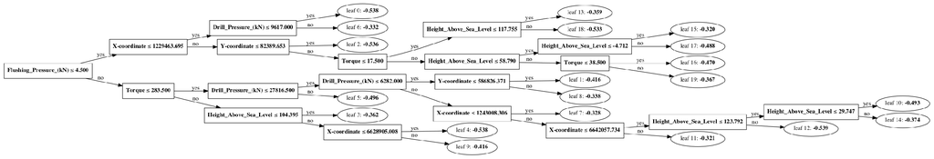

```python
# This line will hide code by default when the notebook is exported as HTML
di.display_html('<script>jQuery(function() {if (jQuery("body.notebook_app").length == 0) { jQuery(".input_area").toggle(); jQuery(".prompt").toggle();}});</script>', raw=True)

# This line will add a button to toggle visibility of code blocks, for use with the HTML export version
di.display_html('''<button onclick="jQuery('.input_area').toggle(); jQuery('.prompt').toggle();">Toggle code</button>''', raw=True)

import lightgbm as lgb
_ = lgb.plot_tree(gbm, figsize = (50,50))
```

> Above is a plot tree describing the flow of how the decision tree understands the relationship between the data features.

The algorithm works as follows: Input: training set $\{(x_i,y_i)\}_{i=1}^n $ a differentiable loss function $\mathbf{L}(y_i,F(x))$, number of iterations M.

Algorithm:

Initialize model with a constant value:

$$F_0(x) = argmin_{\gamma}\sum_{i=1}^n L(y_i,\gamma)$$

For m = 1 to M:

1. Compute so-called pseudo-residuals:

$$r_{im} = \left[ \frac{\partial L(y_i,F(x_i))}{\partial F(x_i)} \right]_{F(x)=F_{m-1(x)}}$$ for i = 1,...,n

2. Fit a base learner (or weak learner, e.g. tree) $h_m(x)$ to pseudo-residuals, i.e. train it using the training set $\{(x_i,r_{im})\}_{i=1}^n$
3. Compute multiplier $\gamma_m$ by solving the following one-dimensional optimization problem:

$$\gamma_m = argmin_\gamma \sum_{i=1}^n L(y_i,F_{m-1}(x_1)+\gamma h_m(x_i))$$

4. Update the model:

$$F_m(x) = F_{m-1}(x)+\gamma_m h_m(x_i)).$$

Output $F_M(x)$.

**[Read more in Wikipedia](https://en.wikipedia.org/wiki/Gradient_boosting)**

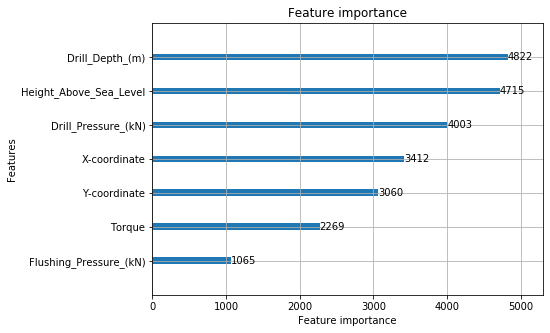

```python
# This line will hide code by default when the notebook is exported as HTML
di.display_html('<script>jQuery(function() {if (jQuery("body.notebook_app").length == 0) { jQuery(".input_area").toggle(); jQuery(".prompt").toggle();}});</script>', raw=True)

# This line will add a button to toggle visibility of code blocks, for use with the HTML export version
di.display_html('''<button onclick="jQuery('.input_area').toggle(); jQuery('.prompt').toggle();">Toggle code</button>''', raw=True)

_ = lgb.plot_importance(gbm, figsize = (7,5))
```

The plot above shows the estimation of feature importance by the trained model to the dependent variable. It believes drill depth is the most important feature, closely followed by the height above sea level and the least important being the flushing pressure.

### IMPROVING MODEL PERFORMANCE BY HYPERPARAMETER TUNING

The developed model was then tuned to optimize for performance. This was done using GridSearchCV to search for the best parameters that could lead to an improvement in accuracy as well as other metrics.

Here, a list of some parameter and hyper-parameter values were fed into the search algorithm were each was tested iteratively to obtain the best set of parameter and hyper-parameters for the model.

Below is a visualization of the variation of mean test score with some parameters.

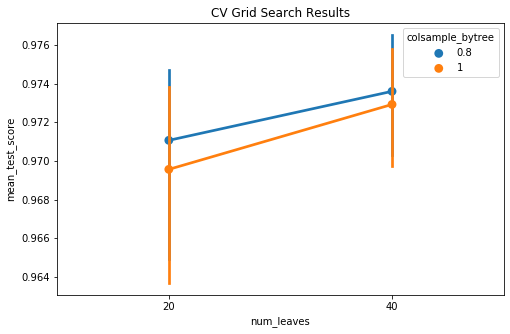

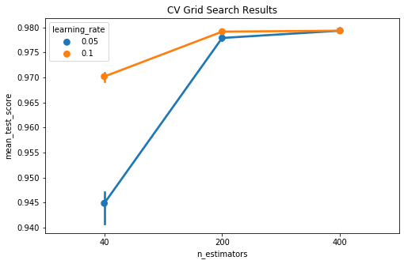

[figure not shown]

```python
# This line will hide code by default when the notebook is exported as HTML
di.display_html('<script>jQuery(function() {if (jQuery("body.notebook_app").length == 0) { jQuery(".input_area").toggle(); jQuery(".prompt").toggle();}});</script>', raw=True)

# This line will add a button to toggle visibility of code blocks, for use with the HTML export version
di.display_html('''<button onclick="jQuery('.input_area').toggle(); jQuery('.prompt').toggle();">Toggle code</button>''', raw=True)

def plot_cv_results(cv_results, param_x, param_z, metric='mean_test_score'):
    """
    cv_results - cv_results_ attribute of a GridSearchCV instance (or similar)
    param_x - name of grid search parameter to plot on x axis
    param_z - name of grid search parameter to plot by line color
    """
    cv_results = pd.DataFrame(cv_results)
    col_x = 'param_' + param_x
    col_z = 'param_' + param_z
    fig, ax = plt.subplots(1, 1, figsize=(8, 5))
    sns.pointplot(x=col_x, y=metric, hue=col_z, data=cv_results, ci=99, n_boot=64, ax=ax)
    ax.set_title("CV Grid Search Results")
    ax.set_xlabel(param_x)
    ax.set_ylabel(metric)
    ax.legend(title=param_z)
    return fig

fig = plot_cv_results(grid.cv_results_, 'n_estimators', 'learning_rate'),
plot_cv_results(grid.cv_results_, 'num_leaves', 'colsample_bytree')
```

### MODEL EVALUATION AND TESTING

The model was then fitted and tested using the test set and this led to a precision score of 92%, recall of 88% and F-1 score of 89%. This means the model performed very well with a good ratio of True Positives and True Negatives to False Positives and False Negatives.

```python
# This line will hide code by default when the notebook is exported as HTML
di.display_html('<script>jQuery(function() {if (jQuery("body.notebook_app").length == 0) { jQuery(".input_area").toggle(); jQuery(".prompt").toggle();}});</script>', raw=True)

# This line will add a button to toggle visibility of code blocks, for use with the HTML export version
di.display_html('''<button onclick="jQuery('.input_area').toggle(); jQuery('.prompt').toggle();">Toggle code</button>''', raw=True)

#Model Accuracy
accuracy = metrics.accuracy_score(y_test, Y_sum)
print('Accuracy: %f' % accuracy)
#Model Precision
precision = metrics.precision_score(y_test, Y_sum, average = 'macro')
print('Precision: %f' % precision)
#Model Recall
recall = metrics.recall_score(y_test, Y_sum, average = 'macro')
print('Recall: %f' % recall)
#Model F1 score
f1 = metrics.f1_score(y_test, Y_sum, average = 'macro')
print('F1 score: %f' % f1)

print("")
#Model Cross validation score
print('Cross-Validation Score: %f' % np.mean(cross_val_score(gbm, X, y, cv=10)))
```

```
Accuracy: 0.976975
Precision: 0.922392
Recall: 0.882383
F1 score: 0.892249

Cross-Validation Score: 0.721386
```

However, the model scored an accuracy of 97.7% which was quite distant from the other classification scores. The model was suspected to be overfitting on the dataset. This was then tested and confirmed the overfit by cross-validating the accuracy of the model on 10 randomly sampled sets of the data and found the mean score to be 72%.

This means the model has the potential to do better with a lot more data points by using a larger dataset. This will mean a lot more SND and Workbook reports to be extracted as this would help improve performance and reduce overfitting.

The model's performance on the test set was also analyzed using SHAP analysis.

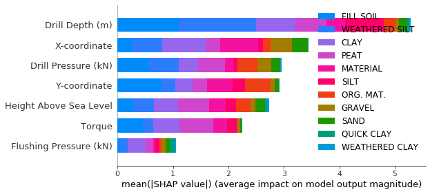

```python
# This line will hide code by default when the notebook is exported as HTML
di.display_html('<script>jQuery(function() {if (jQuery("body.notebook_app").length == 0) { jQuery(".input_area").toggle(); jQuery(".prompt").toggle();}});</script>', raw=True)

# This line will add a button to toggle visibility of code blocks, for use with the HTML export version
di.display_html('''<button onclick="jQuery('.input_area').toggle(); jQuery('.prompt').toggle();">Toggle code</button>''', raw=True)

shap_values = shap.TreeExplainer(gbm).shap_values(X_test)
shap.summary_plot(shap_values, X_test, class_names=['CLAY',
'SILT',
'WEATHERED CLAY',
'SAND',
'QUICK CLAY',
'ORG. MAT.',
'FILL SOIL',
'MATERIAL',
'PEAT',
'WEATHERED SILT',
'GRAVEL'])
```

The below shows the model's understanding of the dependence of some of the other independent features with the drill depth in the test set.

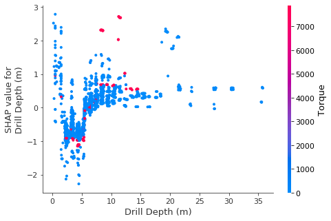

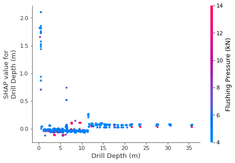

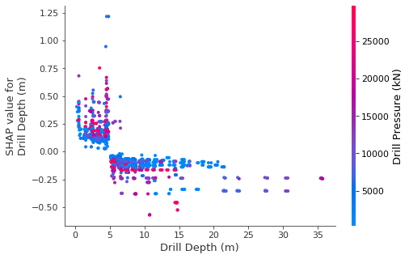

```python
# This line will hide code by default when the notebook is exported as HTML
di.display_html('<script>jQuery(function() {if (jQuery("body.notebook_app").length == 0) { jQuery(".input_area").toggle(); jQuery(".prompt").toggle();}});</script>', raw=True)

# This line will add a button to toggle visibility of code blocks, for use with the HTML export version
di.display_html('''<button onclick="jQuery('.input_area').toggle(); jQuery('.prompt').toggle();">Toggle code</button>''', raw=True)

shap.dependence_plot("Drill Depth (m)", shap_values[8], X_test)
shap.dependence_plot("Drill Depth (m)", shap_values[10], X_test)
shap.dependence_plot("Drill Depth (m)", shap_values[3], X_test)
```

### RECOMMENDATION

In order to build a better model, a lot more data points need to be provided by using a much larger dataset. This will mean a lot more drill data files and Workbook reports to be parsed and extracted as this would help improve performance and reduce overfitting.

The program working on the present data repository (GEOML Folder) takes less than 20 minutes to run. This could be greatly improved by making use of GPU engines to multi-thread the process and make efficient use of memory bandwidth thereby improving speed especially on a much larger dataset.

## PHASE 5 - MODEL DEPLOYMENT

### BATCH PREDICTION

The model can be used to generate predictions for new sets of data all at once and then take action on a certain percentage or size of the data. This will typically have a high latency requirement given that the size of observation sets passed into it may be large or may be at high speed and would require an equally quick response from the deployed model.

### WEB SERVICE & REAL-TIME PREDICTION

At this point, the model must have been moved from a local computer to a cloud service where it will be able access resources necessary to update itself and give predictions in real-time.

It will then be made accessible through the web which will make it available in locations which may be very difficult to have connection to a local server.

Some cloud services which can make this possible include Amazon Web Services(AWS), Microsoft Azure, Digital Ocean, Alibaba cloud, Google Cloud Platform(GCP) and many more which are at various costs and other differences.

[figure not shown]

### STREAM LEARNING

The deployed ML model would then keep updating itself with new streams of data which would improve predictions and output. This would help ensure that the model is not stagnant (concept drift) and gives predictions based on only developmental data.

The model would be exposed to a data source which will supply the new training data which will also contain the target variable. This process will be automated and occur at a selected number of times using limited computing and storage capabilities.

```python
!jupyter nbconvert --to html Geosurvey_ML.ipynb
```